# ggplot2: 19 Programming with ggplot2

This notebook is based on exercises completed from [ggplot2: Elegant Graphics for Data Analysis](https://ggplot2-book.org/index.html).

```r
library(tidyverse)

# set theme for all plots
theme_set(theme_bw())
```

## 19.2.1 Single Component Exercises

1.Create an object that represents a pink histogram with 100 bins.

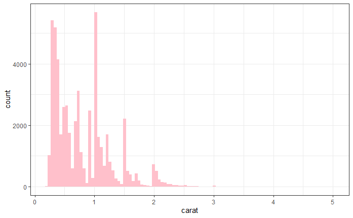

```r
# with function
hist_fn <- function(bins = 100, fill = "pink", ...)  {

  geom_histogram(bins = 100, fill = "pink")
}

ggplot(diamonds, aes(carat)) +
  hist_fn()
```

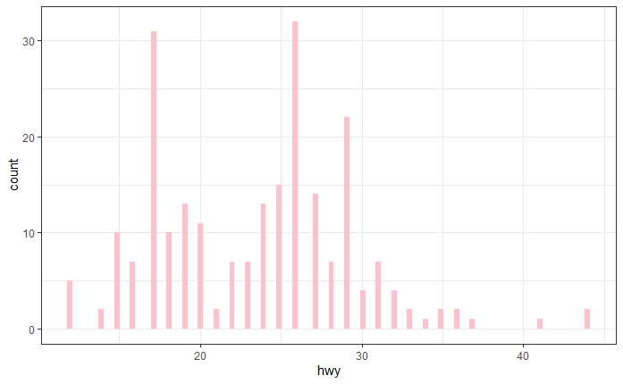

```r
# with object from YX
pink_hist <- geom_histogram(bins = 100, fill="pink")
ggplot(mpg, aes(hwy)) +
pink_hist
```

```r
NA
NA
```

2.Create an object that represents a fill scale with the Blues ColorBrewer palette.

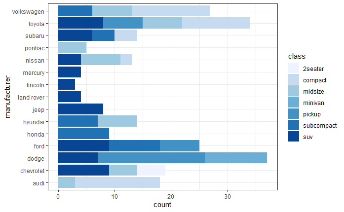

```r
myPalette <- scale_fill_brewer(palette = "Blues")

ggplot(mpg, aes(manufacturer, fill = class)) +
  geom_bar() +
  myPalette +
  coord_flip()
```

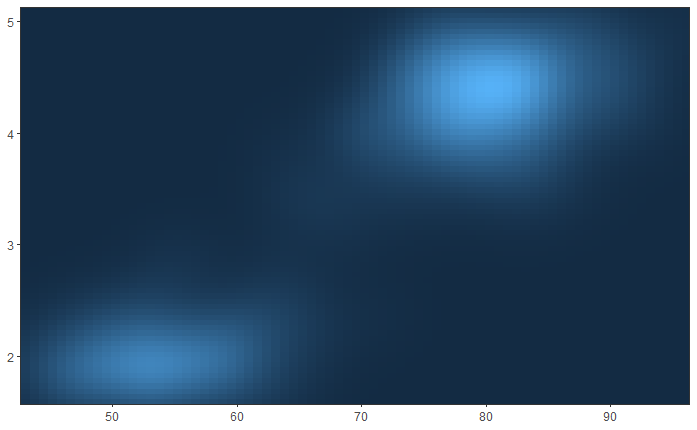

```r
# eruption example
erupt <- ggplot(faithfuld, aes(waiting, eruptions, fill = density)) +
geom_raster() +
scale_x_continuous(NULL, expand = c(0, 0)) +
scale_y_continuous(NULL, expand = c(0, 0)) +
theme(legend.position = "none")
erupt
```

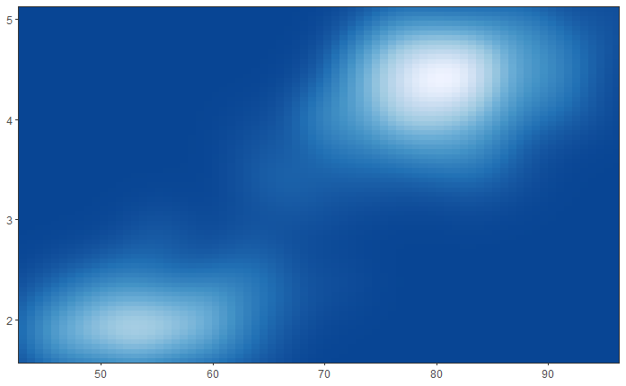

```r
blue_palette <- scale_fill_distiller(palette = "Blues")
erupt+blue_palette
```

```r
NA
NA
```

3.Read the source code for theme_grey(). What are its arguments? How does it work?

The signature ggplot2 theme with a grey background and white gridlines, designed to put the data forward yet make comparisons easy. Read more about ggplot themes online including [theme_grey source code](http://applied-r.com/themes-ggplot/)

```r
# theme_grey()
theme_grey <- function (base_size = 12, base_family = "") {
   require(grid)
   theme(line = element_line(colour = "black", size = 0.5, linetype = 1, lineend = "butt"),
   rect = element_rect(fill = "white", colour = "black", size = 0.5, linetype = 1),
   text = element_text(family = base_family,face = "plain", colour = "black",
   size = base_size, hjust = 0.5, vjust = 0.5, angle = 0, lineheight = 0.9),
   axis.text = element_text(size = rel(0.8), colour = "grey50"),
   strip.text = element_text(size = rel(0.8)),
   axis.line = element_blank(),
   axis.text.x = element_text(vjust = 1),
   axis.text.y = element_text(hjust = 1),
   axis.ticks = element_line(colour = "grey50"),
   axis.title.x = element_text(),
   axis.title.y = element_text(angle = 90),
   axis.ticks.length = unit(0.15, "cm"),
   axis.ticks.margin = unit(0.1, "cm"),

   legend.background = element_rect(colour = NA),
   legend.margin = unit(0.2, "cm"),
   legend.key = element_rect(fill = "grey95", colour = "white"),
   legend.key.size = unit(1.2, "lines"),
   legend.key.height = NULL,
   legend.key.width = NULL,
   legend.text = element_text(size = rel(0.8)),
   legend.text.align = NULL,
   legend.title = element_text(size = rel(0.8), face = "bold", hjust = 0),
   legend.title.align = NULL,
   legend.position = "right",
   legend.direction = NULL,
   legend.justification = "center",
   legend.box = NULL,

   panel.background = element_rect(fill = "grey90", colour = NA),
   panel.border = element_blank(),
   panel.grid.major = element_line(colour = "white"),
   panel.grid.minor = element_line(colour = "grey95", size = 0.25),
   panel.margin = unit(0.25, "lines"),

   strip.background = element_rect(fill = "grey80", colour = NA),
   strip.text.x = element_text(),
   strip.text.y = element_text(angle = -90),

   plot.background = element_rect(colour = "white"),
   plot.title = element_text(size = rel(1.2)),
   plot.margin = unit(c(1, 1, 0.5, 0.5), "lines"), complete = TRUE)
}
```

4.Create scale_colour_wesanderson(). It should have a parameter to pick the palette from the wesanderson package, and create either a continuous or discrete scale.

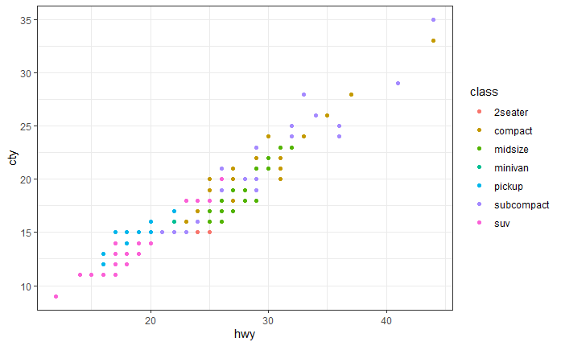

```r
 scale_colour_wesanderson <- function(..., mynumber, myname, mytype) {

   require(wesanderson)

  scale_color_manual(values = wes_palette(mynumber, name = myname, type = mytype))

 }

p <- ggplot(mpg, aes(hwy, cty, color = class)) +
  geom_point()
p
```

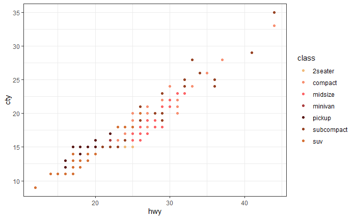

```r
p +
  scale_colour_wesanderson(mynumber = 7,
                           myname = "GrandBudapest1",
                           mytype = "continuous")
```

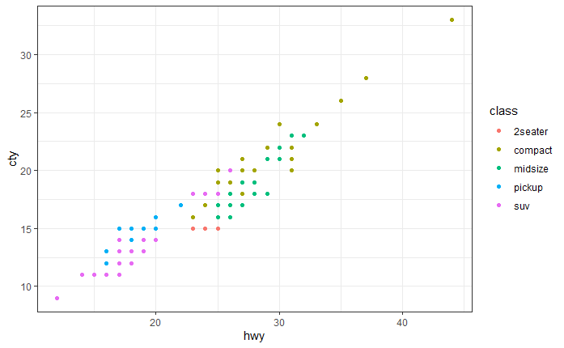

```r
# or use less for discrete example
p2 <- mpg %>%
  filter(class %in% c("2seater", "compact", "midsize", "pickup", "suv")) %>%
  ggplot(aes(hwy, cty, color = class)) +
  geom_point()
p2
```

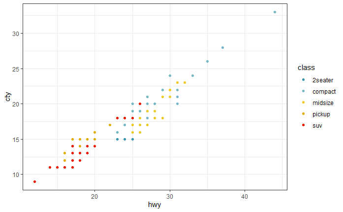

```r
p2 +
  scale_colour_wesanderson(mynumber = 5,
                           myname = "Zissou1",
                           mytype = "discrete")
```

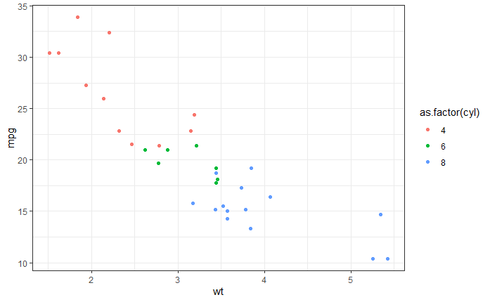

```r
# a different version
# why is function not working with continuous?
library(wesanderson)

scale_colour_wesanderson <- function(parameter){
  scale_color_manual(values = wes_palette(n = 3,parameter))
}
scale_colour_wesanderson_continous <- function(parameter){
  scale_color_manual(values = wes_palette(n = 3,name = parameter,type = "continuous"))
}
p <- ggplot(mtcars, aes(x = wt, y = mpg, color = as.factor(cyl))) +
  geom_point()
p
```

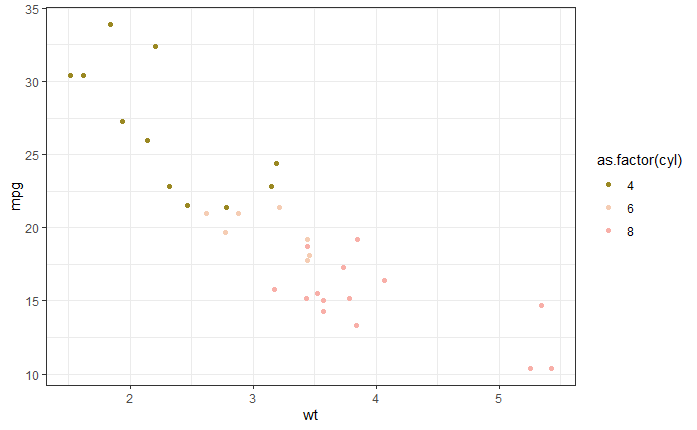

```r
p +  scale_colour_wesanderson("Royal2")
```

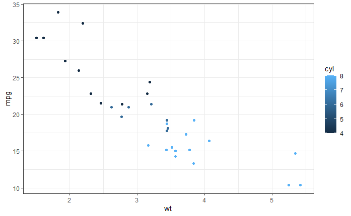

```r
p2 <- ggplot(mtcars, aes(x = wt, y = mpg, color = cyl)) +
  geom_point()
p2
```

```r
# not working?
# p2 + scale_colour_wesanderson_continous("Royal2")
# Error: Continuous value supplied to discrete scale
```

## 19.3.4 Multiple Component Exercises

1.To make the best use of space, many examples in this book hide the axes labels and legend. I’ve just copied-and-pasted the same code into multiple places, but it would make more sense to create a reusable function. What would that function look like?

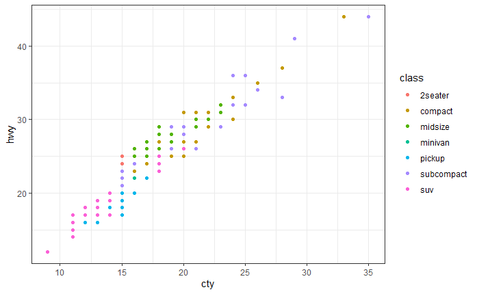

```r
# as function
removeAxes_fn <- function(...) {

  theme(axis.title = element_blank(),
        axis.text = element_blank(),
        axis.ticks = element_blank(),
        legend.position = "none")

}

# as object
removeAxes <- theme(axis.title = element_blank(),
        axis.text = element_blank(),
        axis.ticks = element_blank(),
        legend.position = "none")

# example graphs
p <- ggplot(mpg, aes(cty, hwy, color = class)) +
  geom_point()
p
```

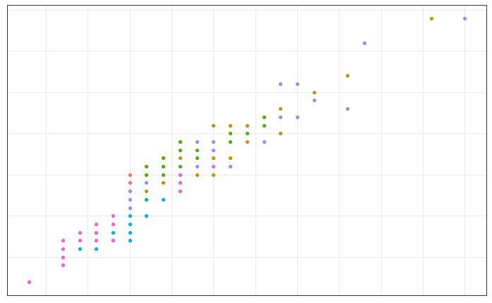

```r
p +
  removeAxes_fn()
```

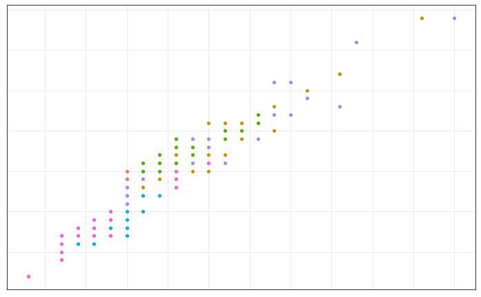

```r
p + removeAxes
```

2.Extend the borders() function to also add coord_quickmap() to the plot.

```r
borders1 <- function(database = "world", regions = ".", fill = NA,
                    colour = "grey50", ...) {
  df <- map_data(database, regions)
  list(geom_polygon(
    aes_(~lat, ~long, group = ~group),
    data = df, fill = fill, colour = colour, ...,
    inherit.aes = FALSE, show.legend = FALSE),
    # asked for coord_quickmap but looks sideways
    coord_quickmap())

}

borders2 <- function(database = "world", regions = ".", fill = NA,
                    colour = "grey50", ...) {
  df <- map_data(database, regions)
  list(geom_polygon(
    aes_(~lat, ~long, group = ~group),
    data = df, fill = fill, colour = colour, ...,
    inherit.aes = FALSE, show.legend = FALSE),
    # asked for coord_quickmap but looks sideways
    #coord_quickmap()
     #,
    # so I choose flip instead
    coord_flip())
}


ggplot() +
  borders1()

ggplot() +
  borders2()

# another example with aes modified instead
borders <- function(database = "world", regions = ".", fill = NA,
colour = "grey50", ...) {
df <- map_data(database, regions)
geom_polygon(
aes_(~long, ~lat, group = ~group),
data = df, fill = fill, colour = colour, ...,
inherit.aes = FALSE, show.legend = FALSE
)
}

if (require("maps")) {
nz <- map_data("nz")
# Prepare a map of NZ
nzmap <- ggplot(nz, aes(x = long, y = lat, group = group)) +
geom_polygon(fill = "white", colour = "black")
# Plot it in cartesian coordinates
nzmap
}

if (require("maps")) {
# With the aspect ratio approximation
nzmap + coord_quickmap()
}

 # With correct mercator projection
nzmap + coord_quickmap() + borders("nz",fill = "pink")
```

[output not shown]

3.Look through your own code. What combinations of geoms or scales do you use all the time? How could you extract the pattern into a reusable function?

I often make font bigger on axis titles and text for power point slides.

Is there any advantage to using function versus object? Functions more flexible as you can add parameters

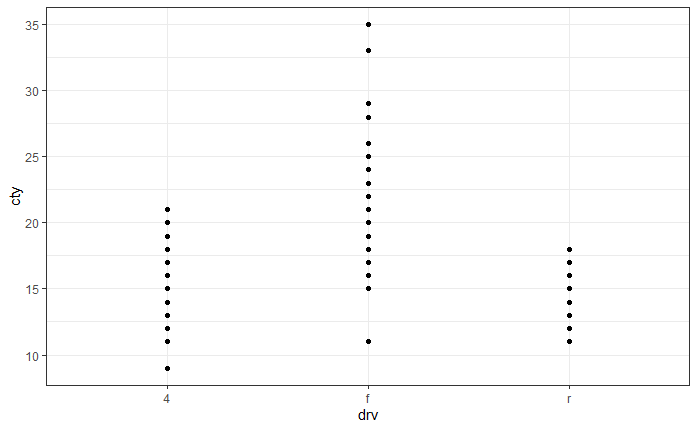

```r
biggerfont <- theme(
        axis.title = element_text(size = 16),
        axis.text =  element_text(size = 14))

ggplot(mpg, aes(drv, cty)) +
  geom_point()
```

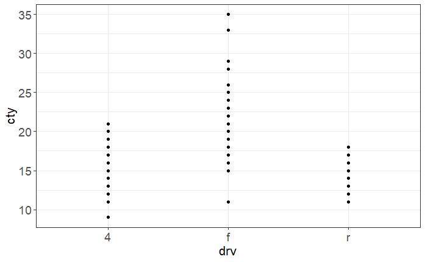

```r
ggplot(mpg, aes(drv, cty)) +
  geom_point() +
  biggerfont
```

```r
NA
NA
```

## 19.4.3 Exercises

1. Create a distribution() function specially designed for visualising continuous distributions. Allow the user to supply a dataset and the name of a variable to visualise. Let them choose between histograms, frequency polygons, and density plots. What other arguments might you want to include?

I added … so I could adjust the number of bins to prevent the warning.

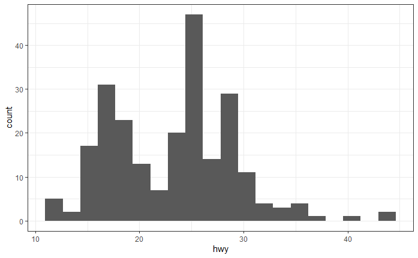

```r
createDistributionFn <- function(dataset, variableName, graphType, ...) {

  p1 <- ggplot(dataset, aes_(as.name(variableName)))

  if (graphType == "histogram") {
  p2 <- p1 +
    geom_histogram(...)
  }

  if (graphType == "freqpoly") {
  p2 <- p1 +
    geom_freqpoly(...)
  }

  if (graphType == "density") {
    p2 <- p1 +
    geom_density(...)
  }

  return(p2)
}

# test all three
createDistributionFn(mpg, "hwy", "histogram", bins = 20)
```

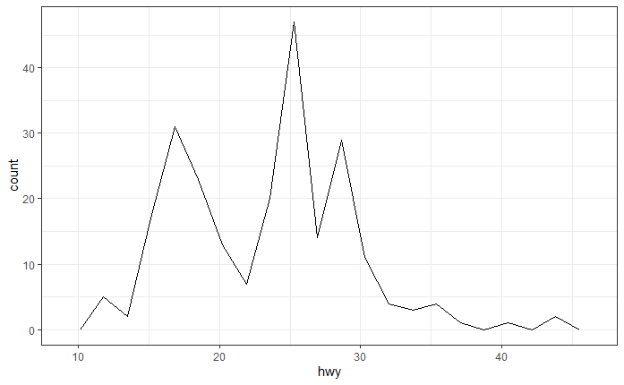

```r
createDistributionFn(mpg, "hwy", "freqpoly", bins = 20)
```

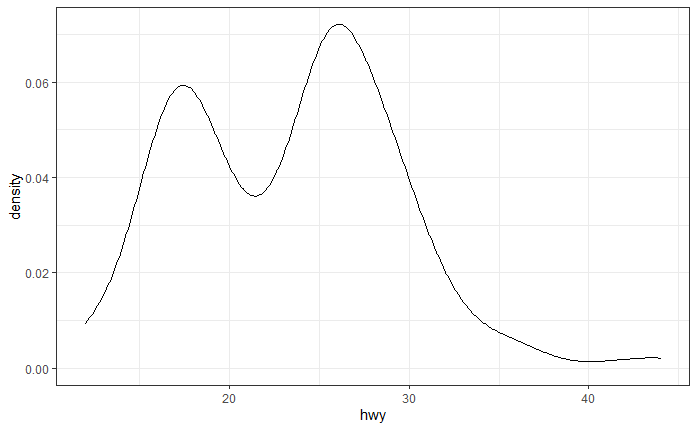

```r
createDistributionFn(mpg, "hwy", "density")
```

2. What additional arguments should pcp() take? What are the downsides of how … is used in the current code?

Additional arguments in the plot could be alpha, color, linetype, size.

The downside of using … like this, is that it is limited to geom_line, and no options can be used within ggplot call. I believe this is necessary to ensure there are no conflicts using … in more than one place.

If want more than one … use seperate functions and put one function within another.

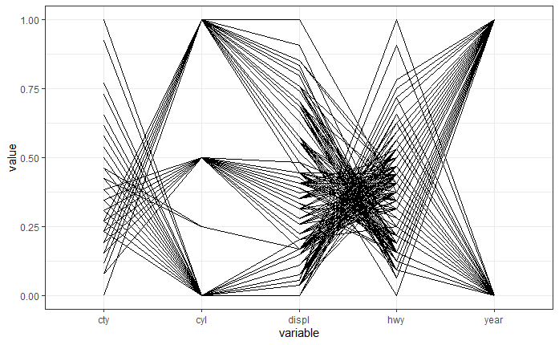

```r
# given
pcp_data <- function(df) {
  is_numeric <- vapply(df, is.numeric, logical(1))

  # Rescale numeric columns
  rescale01 <- function(x) {
    rng <- range(x, na.rm = TRUE)
    (x - rng[1]) / (rng[2] - rng[1])
  }
  df[is_numeric] <- lapply(df[is_numeric], rescale01)

  # Add row identifier
  df$.row <- rownames(df)

  # Treat numerics as value (aka measure) variables
  # gather_ is the standard-evaluation version of gather, and
  # is usually easier to program with.
  tidyr::gather_(df, "variable", "value", names(df)[is_numeric])
}

pcp <- function(df, ...) {
  df <- pcp_data(df)
  ggplot(df, aes(variable, value, group = .row)) + geom_line(...)
}

# to visualize the data
dfTest <- pcp_data(mpg)

# graph it
pcp(mpg)
```

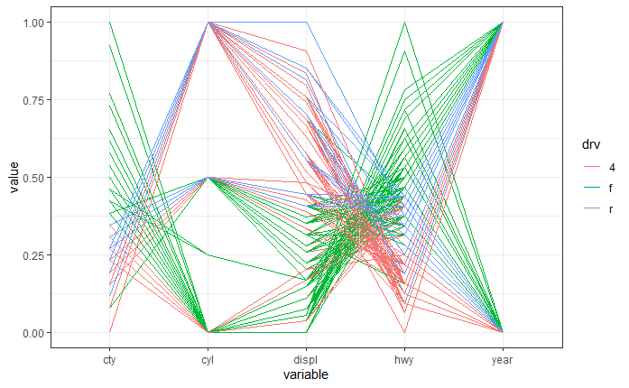

```r
pcp(mpg, aes(colour = drv))
```

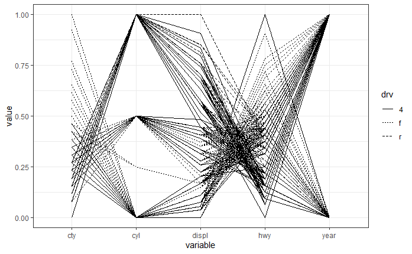

```r
# add other options
pcp(mpg, aes(linetype = drv))
```

3. Advanced: why doesn’t this code work? How can you fix it?

The first problem is that piecharts are now defunct and replaced by pie which works differently. The second problem is that this appears to be fixed in ggplot updates as the example of a function not working works now.

```r
# #given
# piechart1 <- function(data, var, ...) {
#   piechart(data, aes_(~factor(1), fill = as.name(var)))
# }
# piechart1(mpg, "class") + theme(legend.position = "none")
#
# piechart2 <- function(data, var, ...) {
#   piechart(data, aes_(~factor(1), fill = var))
# }
# piechart2(mpg, ~class) + theme(legend.position = "none")
#
# piechart3 <- function(data, var, ...) {
#   piechart(data, aes_(~factor(1), fill = substitute(var)))
# }
# piechart3(mpg, class) + theme(legend.position = "none")
#
# f <- function() {
#   levs <- c("2seater", "compact", "midsize", "minivan", "pickup",
#     "subcompact", "suv")
#   piechart3(mpg, factor(class, levels = levs))
# }
# f()
#
# this runs with R 4.1.0 but not on R 4.0.4
# f2 <- function() {
#   levs <- c("2seater", "compact", "midsize", "minivan", "pickup",
#     "subcompact", "suv")
#   piechart3(mpg, class, levels = levs)
# }
# f2()

# this given as example of why function do Not work
# it works though so updates must have addressed this
f <- function() {
  n <- 10
  geom_line(aes(x / n))
}
df <- data.frame(x = 1:3, y = 1:3)
ggplot(df, aes(x, y)) + f()
```

[output not shown]

## 19.5.1 Exercises

1. How could you add a geom_point() layer to each element of the following list?

```r
plots <- list(
  ggplot(mpg, aes(displ, hwy)),
  ggplot(diamonds, aes(carat, price)),
  ggplot(faithfuld, aes(waiting, eruptions, size = density))
)

# create function to add point layer
addpointlayerFn <- function(x) {
  x +
    geom_point()
}

# test that it works out of list
addpointlayerFn(ggplot(mpg, aes(displ, hwy)))
```

[output not shown]

```r
# add to all layers of list
lapply(plots, addpointlayerFn)
```

[output not shown]

```r
# another way YX
lapply(plots, function(g) g + geom_point())
```

[output not shown]

```r
# another way is map
purrr::map(plots, addpointlayerFn)
```

[output not shown]

2. What does the following function do? What’s a better name for it?

displays each step of ggplot between each step. I would call it layersFn Some say sequential function

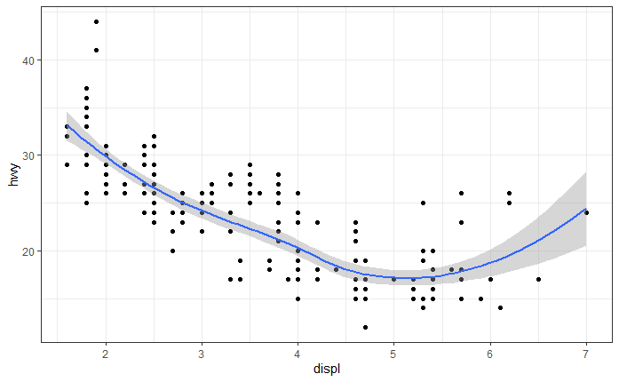

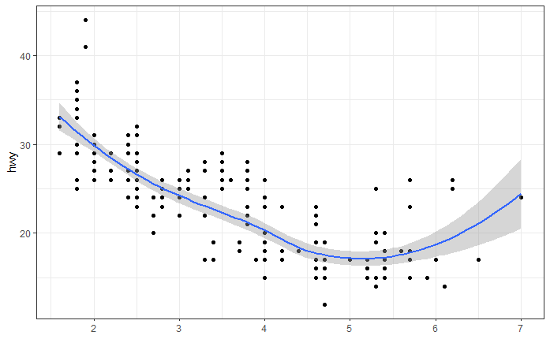

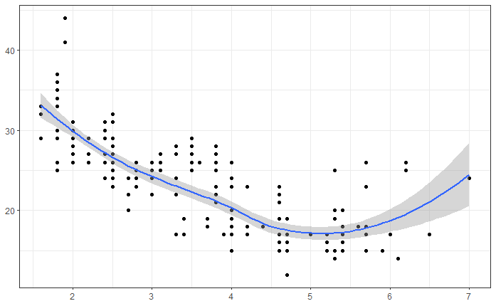

```r
mystery <- function(...) {
  Reduce(`+`, list(...), accumulate = TRUE)
}

mystery(
  ggplot(mpg, aes(displ, hwy)) + geom_point(),
  geom_smooth(),
  xlab(NULL),
  ylab(NULL)
)
```

[output not shown]

```r
# another way to see how it works
  Reduce(`+`, list(1,2,3,4), accumulate = TRUE)
```

```
[1]  1  3  6 10
```